# Homework 1 assignment

wd2234

This famous (Fisher’s or Anderson’s) iris data set consists of 50 samples from each of three species of flower(Setosa, Virginica and Vericolor). There are four variables that measure four features of each flower sample: petal length, petal width, septal length, and septal width, in centimeters.Since it is a R dataset package, there is no need to import data.

```r
attach(iris)
library(ggplot2)
```

# scatterpoint plot

There is a positive and approximately linear association between sepal length and width. Meanwhile, Virginica has a relatively higher sepal length at the same level of sepal width, compared to versicolor and setosa.

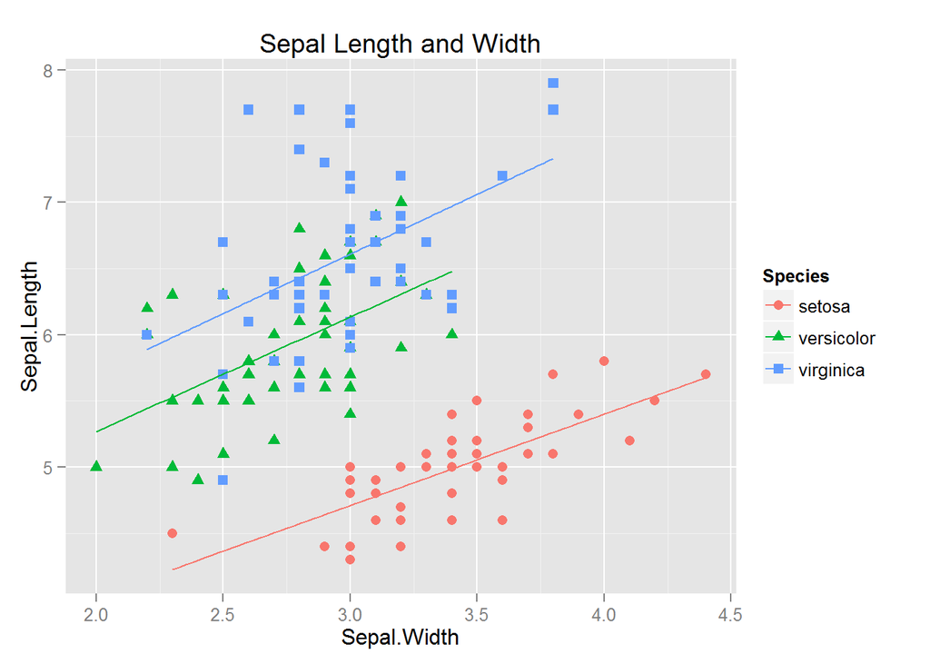

There is a positive and approximately linear association between petal length and width. Meanwhile, Virginica has the largest size petal, with highest level of both petal length and width on average. Versicolor comes second place, and setosa tends to have very small-sized petal.

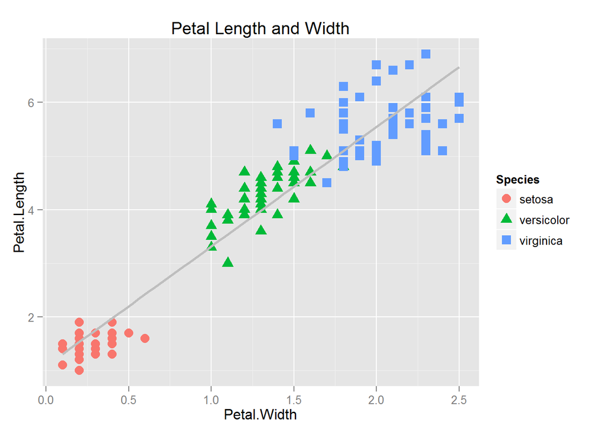

# Boxplot,jitter plot and violin plot

These plots also shows that virginica has a relatively high sepal length, versicolor comes second, and setosa comes last.

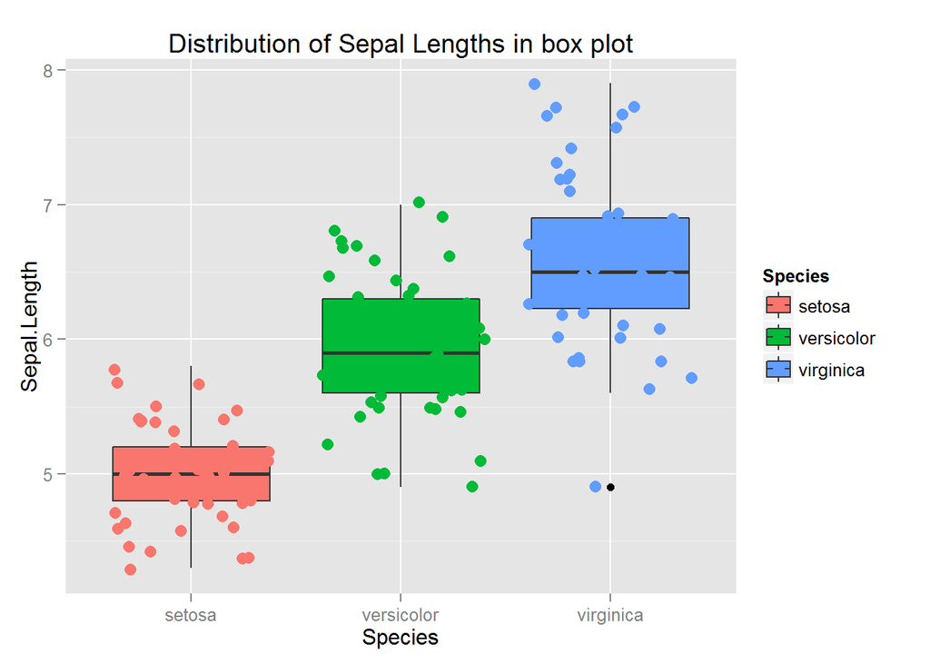

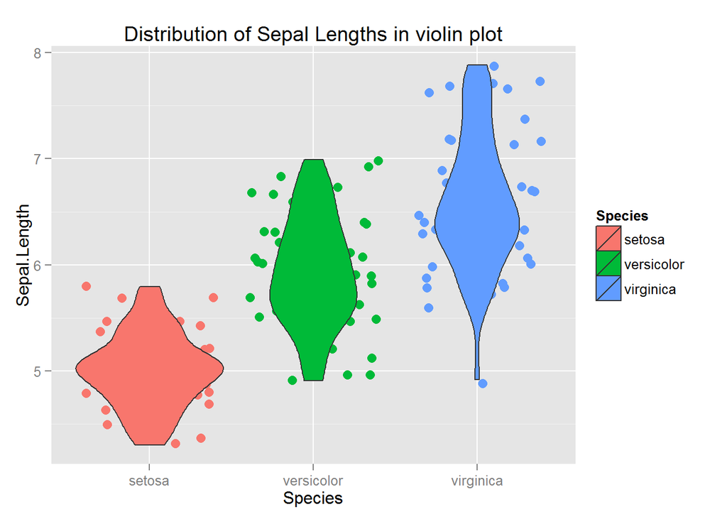

# Bar plot

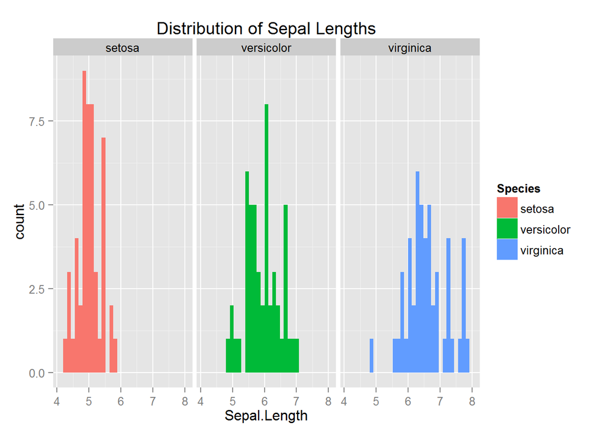